# Data Carpentry R Workshop Follow-up 1/18/18

Alex Bajcz

Last updated: January 17, 2018

## Introduction

This document/lesson is designed to be a follow-up to the materials presented on Day 2 of the Data Carpentry workshop. On Day 2, we covered:

- The basics of the R language and of R usage (i.e., functions, scripts, objects, importing data, indexing, and vectors).
- Data manipulation and summarization using the package *dplyr*.
- Data graphing and representation using the package *ggplot2*.
- Data reporting and communication using the package *knitr*.

If you did not take the Data Carpentry lesson before reading this and you want to freshen up on these topics, you can access and review all the lesson materials we used [here](https://uw-madison-aci.github.io/2018-01-08-uwmadison-dc/).

This document is meant to be a supplement to those lessons, introducing three new concepts that will “elevate” your R skills to new heights:

- Creating date variables using separate day, month, and year variables, which will enable new graphing options.
- The logical function *which*(), the control function *for*(), and the hybrid function *if*() and their many uses.
- The process and syntax for creating custom R functions.

## Getting our data file for the lesson

For this lesson, we’ll use the cleaned-up version of the portal data set we used in the Data Carpentry lessons linked to above.

```r
download.file("http://kbroman.org/datacarp/portal_clean.csv",
    "portal_clean.csv")  #This will put the file into your working directory, which is whatever you've set it to. You can change this by either using the 'Projects' feature we showed you, or you can change this by going to the 'Session' menu and selecting the 'Set Working Directory' option and choosing the directory you would like to be working in.

surveys = read.csv("portal_clean.csv")  #This reads in the file, so long as its in your current directory. You'll notice I'm using the = assignment operator and will be throughout. Recognize that = and <- work the same way!
```

## Part 1 – Dates

Working with dates in R or any similar program can be a challenge, as we discussed in the workshop. We recommend that you store date information in separate day, month, and year columns. This gives you some flexibility in how you sort, summarize, and graph your data. It’s also easier to turn your separate columns back into dates in R than it is to do the reverse, in my experience. But we might want to have a date column nonetheless–something R recognizes to be a date. To do that, we’re going to need to follow a few steps.

First, we need to know what time zone R thinks we are in.

```r
Sys.timezone()  #This function tells you what R thinks your time-zone is where you are. May not work on all systems!
```

```
## [1] "America/Chicago"
```

I may have forgotten to mention in the workshop that there is a fast way to index whole columns of a data frame–by using the $ operator and the column’s name.

```r
surveys$sex[1:100]  #Returns the whole column as a vector, here restricted to just the first 100 entries for space. We'll be using this indexing trick throughout this lesson.
```

```
##   [1] M M M M M M F F F F F F M M F M M M F M F F F F F F F F M F F F F F F
##  [36] M M M F F M F M F F F F F M F F F M F M F M M M M M M F M F M F M F M
##  [71] F F M F M F F M M M M M M F M F F F F F F F M M M F F F F F
## Levels: F M
```

Now, we can use the *ISOdate*() function to convert our separate date columns to a single column with information R will recognize as date information.

```r
full_dates = ISOdate(surveys$year, surveys$month, surveys$day,
    tz = Sys.timezone())  #Will stitch together the time columns into a single text string for each row with date and time info. Omit the tz argument if the Sys.timezone function doesn't work on your system.
```

That’s good, but if we look at the full dates, we’ll see we get meaningless time information this way.

```r
full_dates[1:10]
```

```
##  [1] "1978-05-06 12:00:00 CDT" "1978-08-05 12:00:00 CDT"
##  [3] "1978-09-04 12:00:00 CDT" "1979-04-29 12:00:00 CDT"
##  [5] "1979-05-30 12:00:00 CDT" "1979-07-04 12:00:00 CDT"
##  [7] "1979-10-25 12:00:00 CDT" "1979-11-17 12:00:00 CST"
##  [9] "1980-01-16 12:00:00 CST" "1980-05-18 12:00:00 CDT"
```

We can then use the *as.Date*() function to remove these needless times. Then, we can store that new date information as a new column called *date* in our *surveys* data frame.

```r
surveys$date = as.Date(full_dates)  #Attaching this as a column to our data frame.

str(surveys)  #We can see that it's there.
```

```
## 'data.frame':    30652 obs. of  14 variables:
##  $ record_id      : int  845 1164 1261 1756 1818 1882 2133 2184 2406 3000 ...
##  $ month          : int  5 8 9 4 5 7 10 11 1 5 ...
##  $ day            : int  6 5 4 29 30 4 25 17 16 18 ...
##  $ year           : int  1978 1978 1978 1979 1979 1979 1979 1979 1980 1980 ...
##  $ plot_id        : int  2 2 2 2 2 2 2 2 2 2 ...
##  $ species_id     : Factor w/ 19 levels "BA","DM","DO",..: 5 5 5 5 5 5 5 5 5 5 ...
##  $ sex            : Factor w/ 2 levels "F","M": 2 2 2 2 2 2 1 1 1 1 ...
##  $ hindfoot_length: int  32 34 32 33 32 32 33 30 33 31 ...
##  $ weight         : int  204 199 197 166 184 206 274 186 184 87 ...
##  $ genus          : Factor w/ 9 levels "Baiomys","Chaetodipus",..: 4 4 4 4 4 4 4 4 4 4 ...
##  $ species        : Factor w/ 18 levels "albigula","baileyi",..: 1 1 1 1 1 1 1 1 1 1 ...
##  $ taxa           : Factor w/ 1 level "Rodent": 1 1 1 1 1 1 1 1 1 1 ...
##  $ plot_type      : Factor w/ 5 levels "Control","Long-term Krat Exclosure",..: 1 1 1 1 1 1 1 1 1 1 ...
##  $ date           : Date, format: "1978-05-06" "1978-08-05" ...
```

### Try it!

Add a date column to your data frame. Then, make the coolest ggplot line graph you can think to make, using *date* as the x variable plus *geom_line*(). Maybe try filtering out some data, grouping by each individual date, and then summarizing using *dplyr* tools.

```r
library(dplyr)  #Load our libraries so we can use their tools.
library(ggplot2)
```

### Example

This graph looks at trends for the species DM in the years 1980 through 1982. It groups the data by date and by sex so that we only have a single mean weight for all animals of each sex observed on each individual date (grouping by individual date prevents weird buzz-sawing that occurs when you have multiple entries on the same date). Then, it graphs these data over time as a line graph, faceted by sex.

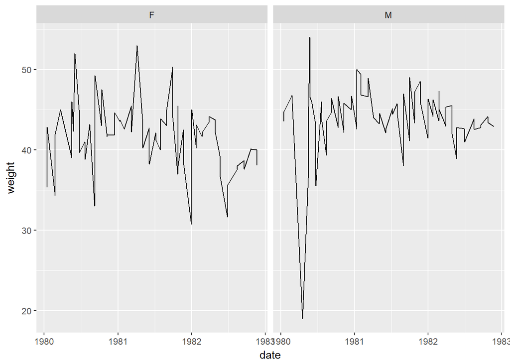

```r
surveys %>% filter(species_id == "DM", year %in% c(1980, 1981, 1982)) %>% # %in% looks for matches between the left and right side--here it's trying to find matches between the year column and the years provided on the right side--1980, 1981, and 1982--keeping only those rows that match.
  group_by(date, sex) %>% summarize (weight = mean(weight)) %>%
  arrange(date) %>% #Annoyingly, the dates are not in chronological order in this data set by default, so we have to put them in order using arrange().
  ggplot(aes(x=date, y=weight)) + geom_line() + facet_wrap(~sex)
```

## Part 2 – The powerful functions *which*(), *for*(), and *if*().

These three functions are ones I think every regular R user should be comfortable with because they’re just so powerful. We’ll start with maybe the simplest of the three, *which*(). *which()* is a **logical function**, meaning it takes a logical rule as input and returns output contingent on whether or not that rule is satisfied. *filter*() in *dplyr* is also a logical function. In *which*()’s case, it returns the entry numbers in the object given as an input that match the rule given as input. For example…

```r
which(surveys$sex == "F")[1:100]  #This tells us which rows in surveys are of females (here, restricted to just the first 100 values to save space)
```

```
##   [1]   7   8   9  10  11  12  15  19  21  22  23  24  25  26  27  28  30
##  [18]  31  32  33  34  35  39  40  42  44  45  46  47  48  50  51  52  54
##  [35]  56  63  65  67  69  71  72  74  76  77  84  86  87  88  89  90  91
##  [52]  92  96  97  98  99 100 107 108 110 113 115 116 117 118 119 120 121
##  [69] 123 124 126 130 131 132 134 135 136 137 138 139 140 142 143 145 146
##  [86] 148 150 151 152 154 155 156 157 158 159 160 163 164 165 166
```

```r
which(surveys$weight < 20 | surveys$weight == 65)[1:100]  #This uses |, which means OR. This returns which rows in surveys have weights that are less than 20 OR are equal to 65.
```

```
##   [1]  371  374  378  698  699  700  701  702  703  704  705  706  707  708
##  [15]  709  710  711  712  717  721  722  723  730  742  745  746  749  750
##  [29]  758  763  775  776  779  781  796  801  803  805  807  813  816  818
##  [43]  834  843  968  969  970  971  972  973  974  975  976  977  978  979
##  [57]  980  981  982  983  985  986  987  988  989  991  992  993  994  995
##  [71]  996  997  998  999 1000 1001 1002 1003 1005 1006 1007 1008 1009 1010
##  [85] 1011 1012 1013 1014 1015 1016 1019 1021 1022 1023 1024 1025 1026 1038
##  [99] 1039 1041
```

```r
which(surveys$weight > 40 & surveys$weight <= 47)[1:100]  #This uses &, which means AND. This returns which rows in surveys have weights greater than 40 but less than or equal to 47.
```

```
##   [1] 171 174 175 178 179 181 184 185 186 190 192 197 199 201 202 204 205
##  [18] 206 207 209 210 211 212 214 216 217 220 222 223 224 226 227 228 231
##  [35] 233 236 239 241 243 245 246 247 249 250 252 253 254 255 257 258 260
##  [52] 262 264 265 268 273 281 283 284 285 286 289 290 291 292 298 301 304
##  [69] 306 307 313 314 315 317 319 322 326 327 333 335 336 337 338 339 340
##  [86] 347 355 356 359 362 363 364 366 367 373 377 386 388 389 392
```

As you can see, you can provide multiple rules to *which*() so long as they are “complete,” meaning R knows exactly which column is being compared to what value(s) in each separate rule you provide on either side of the | or &.

*which*() can be used to make subsets of data in a similar way as *filter*() can (although filter is undoubtedly easier to use!)

```r
all_females = surveys[which(surveys$sex == "F"), ]  #Figure out which rows have a female, and then only keep those rows.
all_females[1:20, ]
```

```
##    record_id month day year plot_id species_id sex hindfoot_length weight
## 7       2133    10  25 1979       2         NL   F              33    274
## 8       2184    11  17 1979       2         NL   F              30    186
## 9       2406     1  16 1980       2         NL   F              33    184
## 10      3000     5  18 1980       2         NL   F              31     87
## 11      3002     5  18 1980       2         NL   F              33    174
## 12      4667     7   8 1981       2         NL   F              30    130
## 15      5299     1  25 1982       2         NL   F              32    165
## 19      5966     5  22 1982       2         NL   F              32     40
## 21      6023     6  28 1982       2         NL   F              30    100
## 22      6036     6  28 1982       2         NL   F              33    120
## 23      6479     8  16 1982       2         NL   F              31    112
## 24      6500     8  16 1982       2         NL   F              33    152
## 25      8022     6  18 1983       2         NL   F              30    126
## 26      8263     8  16 1983       2         NL   F              32    147
```

[output cut: 27 more lines]

*which*() can also be used repeatedly to make new columns that are more complex than *mutate*() in *dplyr* could make. For example, what if we wanted to create a new categorical variable, *weight_class*, that divides our animals into three different weight classe: small, medium, and large? We could do that using *which*().

```r
surveys$weight_class = NA  #This makes an empty column in surveys called weight_class that is just full of NA values to start with.
surveys$weight_class[which(surveys$weight <= 30)] = "small"  #Find every weight entry that is <= 30 and make the corresponding entries in weight_class = 'small'
surveys$weight_class[which(surveys$weight >= 60)] = "large"  #Make a large class in the same manner.
surveys$weight_class[which(surveys$weight > 30 & surveys$weight <
    60)] = "medium"  #Make a medium class.

surveys$weight_class[300:350]  #As we can see, we've made this column.
```

```
##  [1] "medium" "medium" "medium" "medium" "medium" "medium" "medium"
##  [8] "medium" "medium" "medium" "medium" "medium" "medium" "medium"
## [15] "medium" "medium" "medium" "medium" "medium" "medium" "medium"
## [22] "medium" "medium" "medium" "medium" "medium" "medium" "medium"
## [29] "medium" "medium" "medium" "medium" "medium" "medium" "medium"
## [36] "medium" "medium" "medium" "medium" "medium" "medium" "medium"
## [43] "medium" "medium" "medium" "medium" "small"  "medium" "medium"
## [50] "medium" "medium"
```

### Try it!

Make your own new categorical variable using *which*(), then make a neat ggplot with those data, perhaps using *geom_boxplot*() with the new category on the x axis.

### Example

These two graphs show the data generated above in two different ways, first as a box plot and then as a bar plot.

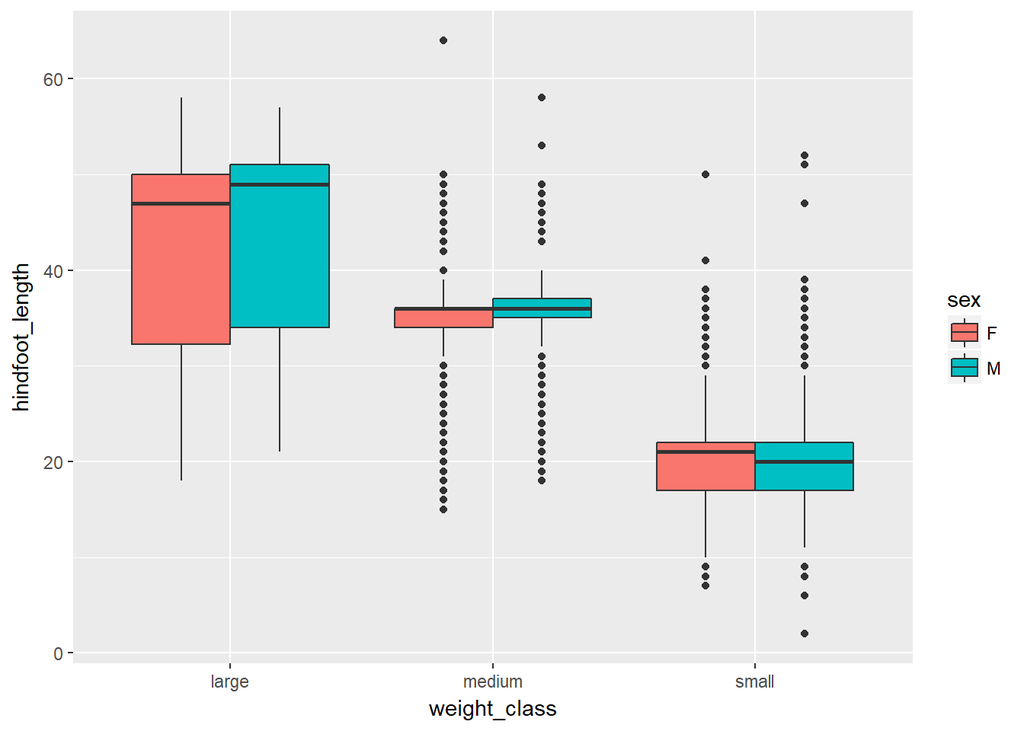

```r
ggplot(surveys, aes(x = weight_class, y = hindfoot_length)) +
    geom_boxplot(aes(fill = sex))  #Medium animals show less variation in hindfoot_length than other animal weight classes. Notice fill is used with box plots and bar plots instead of color, generally!
```

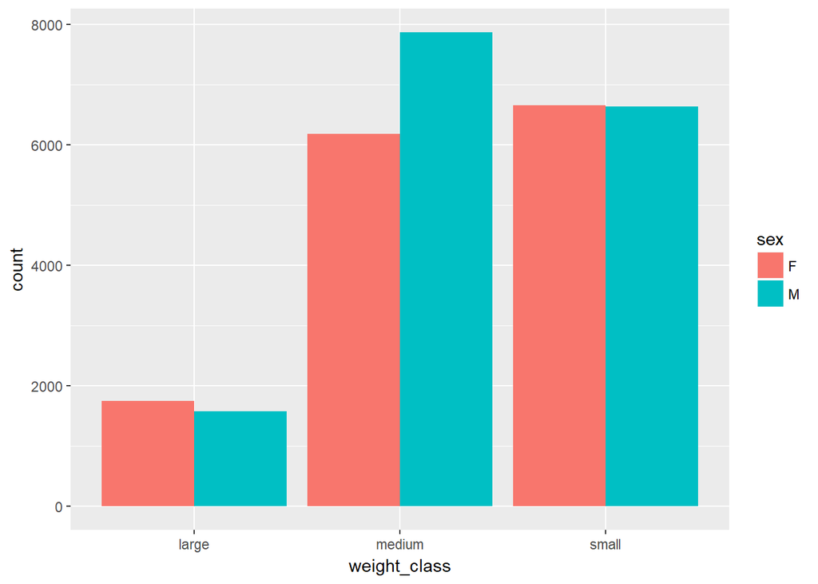

```r
ggplot(surveys, aes(x = weight_class)) + geom_bar(aes(fill = sex),
    position = "dodge")  #there are many more males than females in the medium weight class. position='dodge' inside of geom_bar() will dodge bars that otherwise would be placed in the same spot apart from one another, as needed. The default is to instead stack them--try it out by removing this argument!
```

## Part 2-2 – *for*()

*for*() is an immensely useful function that every regular R user should know. Why? Because, using *for*(), you can make R do something repetitive for you in seconds that otherwise would have taken hours to do by hand or dozens of lines of code to do otherwise.

*for*() is a **control function**–it controls or changes R’s behavior so that it interprets code differently than it otherwise would. Specifically, it forces R to repeat the same code over and over again, perhaps with modifications each time. This is why *for*() calls are often called *for* “loops;” you are causing R to loop over the same code multiple times. How it does this is a little weird though.

Here’s the basic structure of a *for*() call/loop:

```
for(variable in pool) { ~Code to loop over~ }
```

*for*() loops have a few parts, as illustrated above. First, *for*() takes two key inputs–a **“variable”** and a **“pool”**, separated by a particle called “in,” which we won’t talk about right now. I will explain what those inputs mean in a second. The second part of a *for*() call is the code to be repeated each time the loop runs. This code is put in **curly braces**, { }. Curly braces help tell R that this region is not “normal code”–it’s *special* code being controlled by a **control function**.

Now, to explain what the *variable* and the *pool* are, let’s think abstractly for a second. If you were going to repeat some repetitive task for a long time, perhaps with modifications each time, there are probably some basic things you’d want to know and keep track of. You’d want to know how many times you’ll repeat the task, as well as what modifications to make each time, if any. You’d also want a way to keep track of which time through the task you’re currently on.

Together, the *variable* and the *pool* do these three things but in kind of a weird way. Here’s how: Every time the *for*() loop runs, *for*() takes a value out of the *pool* and makes the *variable* equal to it. In other words, the *variable* is an **object** whose *name* stays the same but whose *content* will change each time the *for*() loop runs. Meanwhile, the *pool* is a **vector** of values, each one a value the *variable* object will eventually take. Because the *variable* needs to take on each value in the *pool* once before the *for*() loop can end, the *for*() loop will run until there are no more values in the *pool* left for the *variable* to take. So, if the *pool* is 5 values long, the *for*() loop will run five times.

…That may have been hard to follow! Let’s see this all in action with a very simple *for*() loop. What this one does is call the *variable* “*blah*” and make the *pool* equal to the values from 1 to 5. This will mean the *for*() loop will run five times, and *blah* will contain 1 the first time, 2 the second time, and so on until it has run out of values to take (which will happen after 5). The command *print(blah)* will show you what value *blah* is holding each time through the loop.

```r
for (blah in 1:5) {
    print(blah)
}
```

```
## [1] 1
## [1] 2
## [1] 3
## [1] 4
## [1] 5
```

R reports the numbers 1 through 5, one at a time, each on its own line, because that is what *blah* equaled each time through the *for*() loop.

Some key things to know about *for*(): As the following code will demonstrate, the *variable* can be any name an object could be named, and the *pool* can contain almost any set of values, including things that are not in any particular order.

```r
for (num in c(-3, 1000, pi)) {
    # Here, our variable is called 'num' instead, and the pool is
    # a vector of three wacky values.
    print(num)
}
```

```
## [1] -3
## [1] 1000
## [1] 3.141593
```

To show the real power of *for*() loops, though, we need to do something more exciting. Let’s make a vector whose values are a mathematical function of the values before them. First, some prep work:

```r
vector1 = rep(NA, times = 10)  #The rep() function repeats a value (or set of values) however many times you tell it to. Here, we are creating a vector of length 10, with all the entries being NA for now. This will be our 'storage vector'' for the values our for() loop will create for us.
vector1[1] = 3  #When we index an object like a vector that doesn't have rows or columns, we can just use a single value. Here, we're changing the first value in vector1 to a 3.
```

Now, for the *for*() loop itself. I mentioned earlier that the *variable* is an object that contains one value from the *pool* at a time. Conveniently, that *variable* object can be used inside of the *for*() loop to do work just like we can do work with any other object we make and give a name to.

```r
for (num in 2:10) {
    # Here, our variable is called 'num' and our pool is 9
    # values, specifically the numbers 2 through 10 in order.
    value = vector1[num - 1]  #Here, we are taking advantage of the fact that num is an object that holds the changing value of a number from the pool. The first time through this code, it will be holding the value 2, so 2 - 1 = 1. As such, 'value'' will hold the first (and only) entry in vector1 after this command runs the first time through.
    new_value = (value * 2) + 4  #Here, we are saying that our new_value should be equal to our old value times 2 and then plus 4.
    vector1[num] = new_value  #Now, we put that new_value into our storage vector, using num to help us put this new value in the right place in that vector.
}
vector1
```

```
##  [1]    3   10   24   52  108  220  444  892 1788 3580
```

Pretty cool, huh?

### Try it!

For only the species DM in only the year 1980, use a *for*() loop to create a new column for the cumulative weights of all the animals observed by a given date in that year. In other words, each row should be the sum of all the rows that came before it.

### Example

Here’s how I would go about doing this.

```r
just_dm = surveys %>% filter(species_id == "DM" & year == 1980) %>%
    arrange(date)  #First, filter the data and put it in chronological order, which may not be necessary if you already put them in order earlier. As you can see, filter() can take ANDs and ORs, just like which() can!

just_dm$cumulative_weight = NA  #Create the new column, which will be empty for now.

just_dm$cumulative_weight[1] = just_dm$weight[1]  #Set the first value in the new column equal to the first value in the normal weight column.

# Then, go row by row through the data set. Each row's
# cumulative weight value should be equal to the previous
# row's cumulative weight value plus the weight value in the
# current row.  I like to call my variables something
# memorable, so I chose 'wgt' here.
for (wgt in 2:nrow(just_dm)) {
    just_dm$cumulative_weight[wgt] = just_dm$cumulative_weight[wgt -
        1] + just_dm$weight[wgt]
}

just_dm$cumulative_weight  #We now have our cumulative weights.
```

```
##   [1]    49    96   136   181   214   243   280   316   363   412   457
##  [12]   505   531   580   605   645   691   737   774   816   853   895
##  [23]   939   978  1014  1053  1101  1148  1197  1234  1282  1321  1366
##  [34]  1406  1450  1511  1553  1599  1639  1690  1730  1766  1814  1857
##  [45]  1894  1940  1980  2034  2086  2130  2173  2215  2258  2296  2345
##  [56]  2390  2430  2474  2525  2572  2622  2662  2709  2751  2774  2798
##  [67]  2839  2875  2918  2966  3012  3057  3105  3151  3193  3237  3275
##  [78]  3326  3365  3401  3442  3498  3537  3578  3624  3666  3713  3755
##  [89]  3792  3835  3873  3923  3963  4008  4056  4103  4145  4196  4242
## [100]  4288  4339  4379  4430  4473  4519  4566  4606  4655  4704  4750
## [111]  4787  4832  4851  4885  4928  4968  5021  5050  5081  5130  5171
## [122]  5198  5228  5272  5315  5371  5419  5462  5510  5555  5585  5635
## [133]  5684  5727  5774  5819  5873  5916  5959  6003  6044  6093  6139
## [144]  6190  6243  6284  6330  6367  6415  6460  6502  6555  6586  6625
## [155]  6654  6694  6734  6782  6807  6849  6901  6921  6959  7002  7030
```

[output cut: 17 more lines]

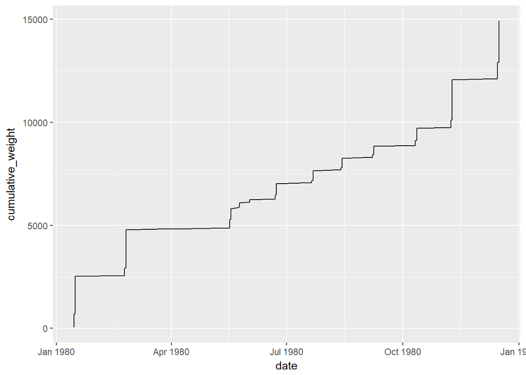

```r
ggplot(just_dm, aes(x = date, y = cumulative_weight)) + geom_line()  #We can plot these using ggplot to see a stair-step pattern.
```

## Part 2-3 – *if*()

Now, time for our last powerful function. *if*() is **both** a **logical function** like *which*() **and** a **control function** like *for*(). So, it takes a logical rule as input and then controls R’s behavior based on the result of that logical rule. Specifically, it *only* runs the code provided to it if the rule is true. Let’s see this in action.

```r
test = 50
if (test > 30) {
    "Yes, test is greater than 30"
}  #If calls have two parts--the logical rule inside the parentheses and the code to execute if the rule is true in curly braces. Here, the rule was true, so the message we put inside the curly braces was returned.
```

```
## [1] "Yes, test is greater than 30"
```

```r
test = 15
if (test > 30) {
    "Yes, test is greater than 30"
}  #Now, here, nothing is returned because the rule is no longer true.
```

But what if you want to do one thing if the rule is true and another thing entirely if it’s not? *if*() has a sister function called *else* for these instances.

```r
if (test > 30) {
    "Yes, test is greater than 30"
} else {
    test * 10
}  #This tells R to run the code inside the if()'s curly braces if the rule given to if() is true and otherwise to run the code in the else()'s curly braces. Here, the rule is not true, so the else code runs!
```

```
## [1] 150
```

A few things are worth noting here–the code inside the curly braces can be one line or hundreds; it doesn’t matter! Second, you’ll notice *else* only gets curly braces, not parentheses. This is because it doesn’t need input–it will only run if the if() logical rule was not true. Third, the *else* has to start on the same line as the *if*() braces close or you will get an error.

For example, this would run.

```
if (test > 30) { "Yes, test is greater than 30"
} else { test * 10 } #The _else_ is on the right line here.
```

But this would return an error because R won’t know the *else* is supposed to go with the *if*() on the previous line.

```
if (test > 30) { "Yes, test is greater than 30" }
else { test * 10 }
```

*if*() is really useful for many things. For example, if you’re designing your own functions (see the next section!), it’s useful for generating warning messages, which will print only if a certain bad condition is met. Another use is inside of *for*() loops–maybe you only want something to happen during a *for*() loop in certain instances and not in others.

```r
just_dm$cumulative_small = NA  #Make the empty vector
just_dm$weight[1] <= 35  #Check to see if the first animal in our data set is 'small.'
```

```
## [1] FALSE
```

```r
just_dm$cumulative_small[1] = 0  #FALSE, so no. In that case, start the count at 0. Maybe you'd need to start it at 1, depending on the rule you want to apply.
```

Now, we can do our *for*() loop. We’re going to go row by row with our *for*() loop, but now what happens each time through will depend on whether the weight value in a given row is above or below a certain threshold. *if*() will handle one of those two cases, and *else* will handle the other.

```r
for (dm in 2:nrow(just_dm)) {
    # Go through each row of the dm data set after the first,
    # which we did manually. Check to see if the current row is
    # less than or equal to 35.
    if (just_dm$weight[dm] <= 35) {
        just_dm$cumulative_small[dm] = just_dm$cumulative_small[dm -
            1] + 1  #If it is, increase the cumulative count by one.
    } else {
        just_dm$cumulative_small[dm] = just_dm$cumulative_small[dm -
            1]  #If not, though, just carry the previous count forward.
    }
}  #Make sure to watch your curly braces! Don't forget to close each set you've made...

just_dm$cumulative_small  #We were successful in creating our new column!
```

```
##   [1]  0  0  0  0  1  2  2  2  2  2  2  2  3  3  4  4  4  4  4  4  4  4  4
##  [24]  4  4  4  4  4  4  4  4  4  4  4  4  4  4  4  4  4  4  4  4  4  4  4
##  [47]  4  4  4  4  4  4  4  4  4  4  4  4  4  4  4  4  4  4  5  6  6  6  6
##  [70]  6  6  6  6  6  6  6  6  6  6  6  6  6  6  6  6  6  6  6  6  6  6  6
##  [93]  6  6  6  6  6  6  6  6  6  6  6  6  6  6  6  6  6  6  6  6  7  8  8
## [116]  8  8  9 10 10 10 11 12 12 12 12 12 12 12 12 13 13 13 13 13 13 13 13
## [139] 13 13 13 13 13 13 13 13 13 13 13 13 13 13 14 14 15 15 15 15 16 16 16
## [162] 17 17 17 18 18 18 18 18 18 18 18 18 18 19 19 19 19 20 21 21 22 22 22
## [185] 22 22 23 23 23 24 24 24 24 24 24 25 26 26 26 26 26 26 26 26 26 26 26
## [208] 26 26 26 26 26 26 26 26 26 26 26 26 26 26 26 26 26 26 26 26 26 26 27
## [231] 27 27 27 27 27 27 27 27 27 27 27 27 27 27 27 27 27 27 27 27 27 27 27
## [254] 27 27 27 27 27 28 28 28 28 28 28 28 28 28 28 28 28 28 28 28 28 28 28
## [277] 28 28 28 28 28 28 28 28 29 29 29 30 31 31 31 31 31 31 31 32 32 32 32
## [300] 32 32 32 32 32 32 32 33 33 33 33 33 33 33 33 34 34 34 34 34 34 34 34
## [323] 34 34 34 34 34 34 34 34 34 34 34 34 34 34 34 34 35 35 35 35 35
```

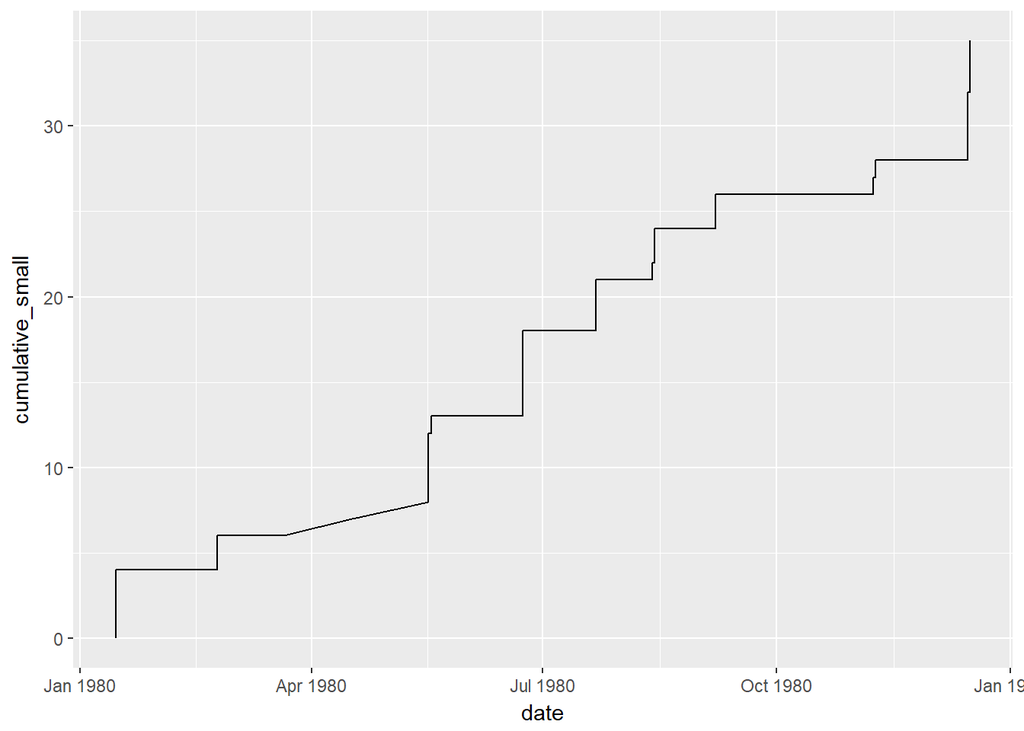

```r
ggplot(just_dm, aes(x = date, y = cumulative_small)) + geom_line()  #We can now plot these data in a similar way as before.
```